# Dæmaverkefni 2: Seinni hluti

Í þessu verkefni haldið þið áfram að vinna með myndræna framsetningu talnabreytna í R. Dæmaverkefni 2 samanstendur af efni síðustu viku og þessarar, svo þið svarið spurningunum sem fylgja hérna á eftir í svarskjalinu frá því í síðustu viku.

Í verkefninu vinnum við með gögn úr `gapminder` gagnasafninu, sem finna má í `gapminder`-pakkanum. Þið þurfið því að hlaða þeim pakka inn í minni. Það er einfaldast að gera með því að bæta við eftirfarandi línu í efsta kóðabútinn í svarskjalið frá því í síðustu viku:

`library(gapminder)`

Kóðabúturinn ætti þá að líta svona út:

```r
library(knitr)
library(tidyverse)
library(googlesheets4)
library(gapminder)

knitr::opts_chunk$set(echo = TRUE,message=FALSE,warning=FALSE)
```

```r
glimpse(gapminder)
```

```
## Rows: 1,704
## Columns: 6
## $ country   <fct> "Afghanistan", "Afghanistan", "Afghanistan", "Afghanistan", …
## $ continent <fct> Asia, Asia, Asia, Asia, Asia, Asia, Asia, Asia, Asia, Asia, …
## $ year      <int> 1952, 1957, 1962, 1967, 1972, 1977, 1982, 1987, 1992, 1997, …
## $ lifeExp   <dbl> 28.801, 30.332, 31.997, 34.020, 36.088, 38.438, 39.854, 40.8…
## $ pop       <int> 8425333, 9240934, 10267083, 11537966, 13079460, 14880372, 12…
## $ gdpPercap <dbl> 779.4453, 820.8530, 853.1007, 836.1971, 739.9811, 786.1134, …
```

- Breytan `country` sýnir ríki
- Breytan `continent` sýnir heimsálfu
- Breytan `year` sýnir ár, en hún tekur gildi frá 1952 til 2007 í fimm ára stökkum
- Breytan `lifeExp` sýnir lífslíkur við fæðingu, í árum
- Breytan `gdpPercap` sýnir verga þjóðarframleiðslu á mann í dollurum árið 2007, leiðrétt fyrir verðbólgu

Munið að vista skjalið ykkar reglulega og vefa það saman annað slagið til að þið getið strax lagfært villur sem gætu komið upp.

# 1 R-verkefni

## 1.1 Hlutfall kvenna á þjóðþingum heimsins (frá því síðast)

## 1.2 Dreifing lífslíkna í löndum heimsins árið 2007

Bætið við nýjum undirkafla (##) fyrir neðan verkefnin sem þið gerðuð í síðustu viku og notið titilinn á þessum kafla sem titil. Búið til kóðabút og setjið fram **stuðlarit** (e. histogram) sem sýnir **dreifingu á lífslíkum** í ríkjum heimsins **árið 2007**. Athugið að þið þurfið að sía (e. filter) gögnin til að halda einungis eftir gögnum fyrir 2007! Ekki nota sjálfgefna talnabilið (`binwidth`), heldur veljið sjálf gildi sem þið teljið samræmast námsefninu.

Túlkið nú grafið fyrir neðan kóðabútinn. Þið getið haft eftirfarandi spurningar til hliðsjónar: Hvað sýnir grafið okkar um dreifingu lífslíkna? Hvaða gildi eru á x-ásnum og hvaða gildi á y-ásnum? Er dreifingin með eina eða margar kryppur? Er dreifingin skekkt? Hvers vegna stilltuð þið talnabilið á gildið sem þið völduð? Svarið með vísun í námsefnið.

## 1.3 Samanburður á dreifing lífslíkna eftir heimsálfu árið 1952 og 2007

Bætið við nýjum undirkafla (##) fyrir neðan svarið að ofan og notið titilinn á þessum kafla sem titil. Búið til kóðabút og setjið fram **kassarit** (e. boxplot) sem sýnir **dreifingu á lífslíkum eftir heimsálfu árin 1952 og 2007**. Nánar tiltekið, þá eigið þið að mappa heimsálfu á x-ás, lífslíkur á y-ás og skipta gögnunum í tvær smámyndir eftir ártali.

Túlkið nú grafið fyrir neðan kóðabútinn. Þið getið haft eftirfarandi spurningar til hliðsjónar (ATH. þið eigið að hunsa “Oceania” heimsálfuna þegar þið svarið eftirfarandi spurningum!): Hvað sýnir grafið okkar um dreifingu lífslíkna í ólíkum heimsálfum? Hvar eru lífslíkurnar mestar? Hvar er mesti breytileikinn? Í hvaða heimsálfu virðast lífslíkur hafa aukist mest? En minnst? Svarið með vísun í námsefnið.

## 1.4 Þróun mannfjölda í Danmörku, Noregi og Svíþjóð

Bætið við nýjum undirkafla (##) fyrir neðan svarið að ofan og notið titilinn á þessum kafla sem titil. Búið til kóðabút og setjið fram línurit sem sýnir þróun mannfjölda yfir tíma í Danmörku, Noregi og Svíþjóð. Þegar þið síið gögnin þá gæti komið sér vel að nota “|” táknið sem stendur fyrir “EÐA” þegar við veljum hvaða röðum við viljum halda eftir. Ártal ætti að fara á x-ásinn og breytan `country` ætti að vera möppuð á `color`, þannig að þrjár litaðar línur verði á grafinu, ein fyrir hvert land. Áður en þið gerið grafið þá skulið þið breyta breytunni `pop` þannig að hún sýni milljónir íbúa í hverju landi (semsagt deila í pop með 1000000 og búa til nýja breytu). Á grafinu ætti y-ásinn að ná frá um það bil 3 í 9.

Túlkið nú grafið fyrir neðan kóðabútinn. Þið getið haft eftirfarandi spurningar til hliðsjónar: Hvernig eru mannfjöldatölur ólíkar í þessum þremur ríkjum? Hefur verið sama þróunin í öllum ríkjunum?

## 1.5 Þróun lífslíkna í löndum heimsins

Bætið við nýjum undirkafla (##) fyrir neðan svarið að ofan og notið titilinn á þessum kafla sem titil. Búið til kóðabút og endurgerið grafið hér að neðan. Athugið að hér reynir á marga ólíka þætti sem við höfum farið yfir á síðustu vikum. Ef þetta vefst fyrir ykkur, þá getur verið gott að vinna þetta skref fyrir skref. Byrjið á því að setja upp línurit með gögnunum. Svo getið þið fundið út úr því hvernig þið setjið inn aðhvarfslínur/jöfnunarlínur, skipt myndinni niður í smámyndir, síað gögnin og svo framvegis. Aðalatriðið er að gera þetta skref fyrir skref!

Eitt til að muna: Þegar þið eruð að mappa breytur á hluta grafsins, til dæmis `group` (sjá myndband um línurit), þá getur skipt máli hvort það sé gert efst í `ggplot` fallinu eða á tilteknum hluta grafsins, til dæmis í `geom_line`. Það gæti borgað sig að velta þessu vel fyrir sér ef aðhvarfslínurnar sem þið setjið á grafið eru óvenju margar miðað við fyrirmyndina.

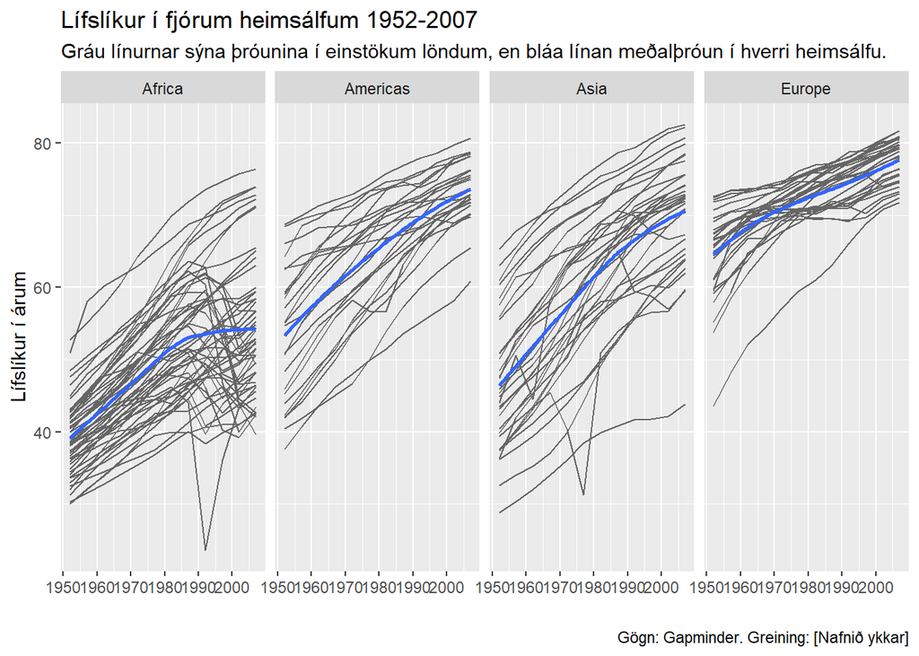

## 1.6 Verkefnaskil

Þá eruð þið komin á leiðarenda! Lokaskjalið ykkar ætti að innihalda svör við öllum dæmaspurningum frá síðustu viku, R spurningunum frá síðustu viku og svo R spurningunum hér að ofan.

Þegar þið eruð búin með verkefnið þá vefið þið það saman í **html** skrá. Farið vel yfir skránna áður en þið skilið henni inn og gangið úr skugga um að öll svörin ykkar birtist eins og þið ætlið ykkur. Þegar þið eruð búin að vefa skránna saman þá getið þið fundið hana í sömu möppu á tölvunni ykkar og R Markdown skránna. Þið skilið svo **html** skránni á viðeigandi stað á Canvas.

Gangi ykkur vel!